# Analisis Factorial

Rubit Fernanda Urquijo Cuevas

21/6/2021

# IMPORTAR LA BASE DE DATOS EN FORMATO EXCEL

```r
library(readxl)
datos<- read_excel("C:/Users/INDEX/Documents/Diseño de Experimentos/Temas Examen Final/af.xlsx")
```

# TIPIFICACION O ESTANDARIZACION DE VARIABLES

La tipificacion permite que todas las variables metricas gocen de una misma unidad de medida estadistica.

```r
datost<- datos #crear una nueva base de datos o data frame
datost<- scale(datost, center = T, scale = T)
datost<- as.data.frame(datost)
```

# NORMALIDAD MULTIVARIANTE

H0: Normalidad multivariante  
H1: No normalidad multivariante  
Confianza= 95%  
Alfa= 5% = 0,05  
P value > alfa: no se rechaza la H0 (Normalidad)  
P value < alfa: se rechaza la H0 (No normalidad)

```r
library(MVN)
mvn(datost[2:6])
```

```
## $multivariateNormality
##              Test        Statistic              p value Result
## 1 Mardia Skewness 446.746983653853 7.07386833522649e-73     NO
## 2 Mardia Kurtosis 11.6070373214253                    0     NO
## 3             MVN             <NA>                 <NA>     NO
##
## $univariateNormality
##           Test          Variable Statistic   p value Normality
## 1 Shapiro-Wilk Nº  del articulo     0.9393    0.0873    YES
## 2 Shapiro-Wilk Cantidad de prod.    0.9652    0.4170    YES
## 3 Shapiro-Wilk   Precio Unidad      0.9271    0.0410    NO
## 4 Shapiro-Wilk     Subtotal         0.8567    0.0009    NO
## 5 Shapiro-Wilk        IVA           0.8567    0.0009    NO
##
## $Descriptives
##                    n          Mean Std.Dev     Median       Min      Max
## Nº  del articulo  30 -4.343151e-16       1  0.1203548 -1.684968 1.474347
## Cantidad de prod. 30 -5.499525e-17       1 -0.1008075 -1.496603 2.458151
## Precio Unidad     30  1.489694e-16       1  0.1189531 -1.553825 1.457176
## Subtotal          30 -4.355195e-17       1 -0.2754638 -1.027476 2.975037
## IVA               30 -8.782535e-17       1 -0.2754638 -1.027476 2.975037
##                         25th      75th        Skew   Kurtosis
## Nº  del articulo  -0.9515555 0.7973508 -0.06217242 -1.3992665
## Cantidad de prod. -0.7696263 0.6843276  0.47344538 -0.6305856
## Precio Unidad     -0.9404732 0.7880645 -0.18323648 -1.3845017
## Subtotal          -0.7624225 0.4888764  1.22073887  0.8596520
## IVA               -0.7624225 0.4888764  1.22073887  0.8596520
```

como el p value < alfa: se rechaza la HO, por lo tanto, no existe normalidad multivariante.

# MATRIZ DE CORRELACIONES

H0: Correlacion = 0 (no hay correlacion)  
H1: Correlacion diferente de 0 (si hay correlacion)

Cuando no se rechaza H0, no se aplica AFE. Se rechace HO, si para aplicar AFE.

```r
library(psych)
corr.test(datost[,2:6])
```

```
## Call:corr.test(x = datost[, 2:6])
## Correlation matrix
##                   Nº  del articulo Cantidad de prod. Precio Unidad Subtotal
## Nº  del articulo              1.00              0.28          0.83     0.69
## Cantidad de prod.             0.28              1.00          0.28     0.75
## Precio Unidad                 0.83              0.28          1.00     0.76
## Subtotal                      0.69              0.75          0.76     1.00
## IVA                           0.69              0.75          0.76     1.00
##                    IVA
## Nº  del articulo  0.69
## Cantidad de prod. 0.75
## Precio Unidad     0.76
## Subtotal          1.00
## IVA               1.00
## Sample Size
## [1] 30
## Probability values (Entries above the diagonal are adjusted for multiple tests.)
##                   Nº  del articulo Cantidad de prod. Precio Unidad Subtotal IVA
## Nº  del articulo              0.00              0.25          0.00        0   0
## Cantidad de prod.             0.14              0.00          0.25        0   0
## Precio Unidad                 0.00              0.13          0.00        0   0
## Subtotal                      0.00              0.00          0.00        0   0
## IVA                           0.00              0.00          0.00        0   0
##
##  To see confidence intervals of the correlations, print with the short=FALSE option
```

```r
correlaciones<- corr.test(datost[,2:6]) #se crea la matriz de correlaciones
correlaciones$r #matriz de correlaciones
```

```
##                   Nº  del articulo Cantidad de prod. Precio Unidad  Subtotal
## Nº  del articulo         1.0000000         0.2750366     0.8304159 0.6853847
## Cantidad de prod.        0.2750366         1.0000000     0.2848048 0.7541803
## Precio Unidad            0.8304159         0.2848048     1.0000000 0.7593693
## Subtotal                 0.6853847         0.7541803     0.7593693 1.0000000
## IVA                      0.6853847         0.7541803     0.7593693 1.0000000
##                         IVA
## Nº  del articulo  0.6853847
## Cantidad de prod. 0.7541803
## Precio Unidad     0.7593693
## Subtotal          1.0000000
## IVA               1.0000000
```

```r
r<- as.matrix(correlaciones$r)
```

# INDICADORES DE APLICABILIDAD DEL AFE (BONDAD DEL AJUSTE)

## CONTRASTE DE ESFERICIDAD DE BARTLETT

H0: Las correlaciones teoricas entre cada par de variables es nulo H1: Las correlaciones teoricas entre cada par de variables no es nulo

P value >alfa: no se aplica el AFE (no se rechaza H0) P value >alfa: si se aplica el AFE (se rechaza H0)

```r
dim(datost) #tamaño de la muestra= 30 personas
```

```
## [1] 30  7
```

```r
cortest.bartlett(r, n= 30)
```

```
## $chisq
## [1] 1121.711
##
## $p.value
## [1] 1.101325e-234
##
## $df
## [1] 10
```

## MEDIDA DE ADECUACION MUESTRAL DE KAISER, MEYER Y OKLIN (KMO)

Estudia variable por variable, si son o no aceptadas en el modelo para hacer AFE. (Que variables elimino o mantengo) Se mantiene una variable en el modelo, si el KMO es igual o mayor a 0,7. Se elimina una variable del modelo, si el KMO es menor a 0,7.

```r
KMO(r)
```

```
## Error in solve.default(r) :
##   sistema es computacionalmente singular: número de condición recíproco = 1.65254e-18
```

```
## matrix is not invertible, image not found
```

```
## Kaiser-Meyer-Olkin factor adequacy
## Call: KMO(r = r)
## Overall MSA =  0.5
## MSA for each item =
##  Nº  del articulo Cantidad de prod.     Precio Unidad          Subtotal
##               0.5               0.5               0.5               0.5
##               IVA
##               0.5
```

KMO= 0.5 El modelo es miserable, no es adecuado para realizar analisis factorial. KMO Nº del articulo= 0.5 (Miserable) KMO Cantidad de prod.= 0.5 (Miserable) KMO Precio Unidad= 0.5 (Miserable) KMO Subtotal= 0.5 (Miserable) KMO IVA= 0.5 (Miserable)

# DETERMINACION DEL NUMERO DE FACTORES A EXTRAER

## Metodo de las componentes principales iteradas (Ejes principales)

Este metodo de las Ejes principales es de naturaleza no parametrica, es decir, que se ocupa, cuando no hay normalidad multivariante; pero, tambin es valido para modelos parametricos (normalidad multivariante)

```r
fa.parallel(r, fm= "pa", n.obs= 30, ylabel= "Eigenvalues")
```

```
## In factor.scores, the correlation matrix is singular, an approximation is used
```

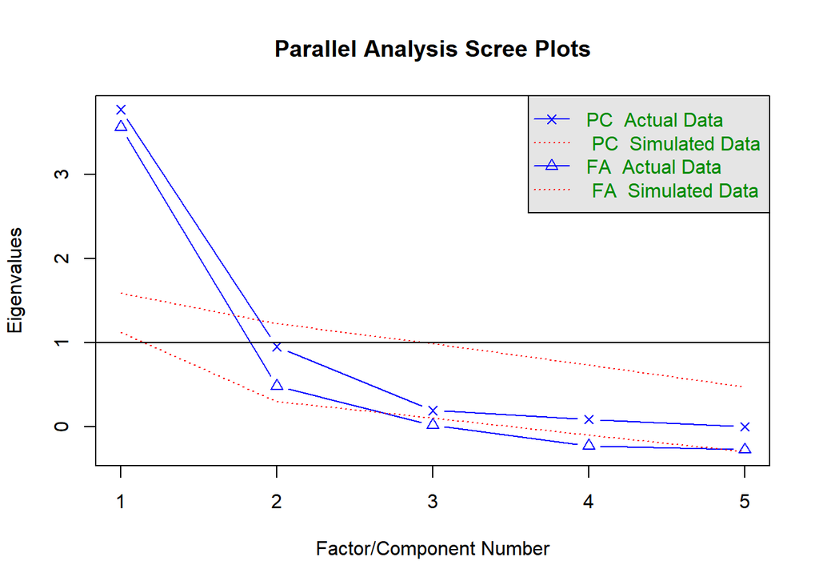

```
## Parallel analysis suggests that the number of factors =  2  and the number of components =  1
```

Con el metodo de los ejes principales se extraeria solo 2 factor.

## Metodo de las componentes principales

Metodo parametrico, sirve solo para modelos con normalidad multivariante

```r
fa.parallel(r, fm= "pc", n.obs= 30, ylabel= "Eigenvalues")
```

[output not shown]

```
## In factor.scores, the correlation matrix is singular, an approximation is used
```

[output not shown]

[output not shown]

[output not shown]

[output not shown]

[output not shown]

[output not shown]

[output not shown]

[output not shown]

[output not shown]

[output not shown]

[output not shown]

[output not shown]

[output not shown]

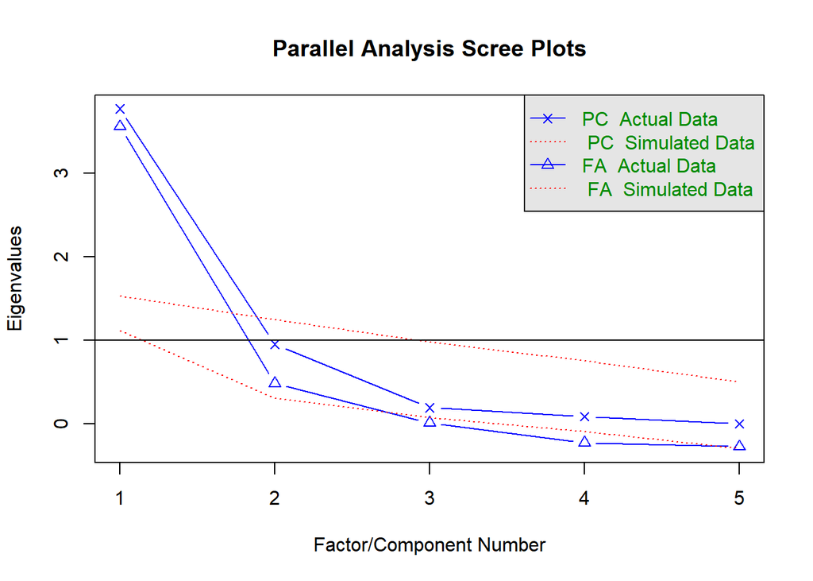

```
## Parallel analysis suggests that the number of factors =  2  and the number of components =  1
```

## Metodo de la maxima verosimilitud

Metodo parametrico, sirve solo para modelos con normalidad multivariante

## Metodo paralelo con iteraciones

Metodo parametrico, sirve solo para modelos con normalidad multivariante